# DSAF_Final_Project

Srija Vakiti & Vaishnavi Asuri

2022-12-08

##USING DATA ANALYSIS TO INFERENCE TRENDS AT SEPHORA

**About the data source:**

This data was scraped as API from **Sephora.com** and compiled by **Florencia Leoni**. We acquired this from her GitHub repository. The code for this can be found in the same repository under **src/Webscraping**.

**(URL:https://github.com/fpleoni/i_feel_pretty/commit/0eb094749e6cbfc92e106d24574054039449e099)** data/skincare_df.csv

One of the two major participants in the beauty retail market, along with Ulta, is **Sephora**, which also leads the industry in terms of online sales. The enormous investment they made in developing a digital beauty brand, which makes the online experience just as wonderful as the brick-and-mortar one, may be used to justify their leadership.

**About the dataset:**

Dataset license: CC0 1.0 Universal (CC0 1.0) - Public Domain Dedication

This dataset includes details on a variety of skincare products like:

- Brand Name
- Product Name
- Retail Price
- Number of reviews
- Number of loves on Instagram
- Product Review Score (out of 5)
- Clean Product Status
- Product Category

**PROBLEM STATEMENT**

**To perform customer analysis and identify the trends at Sephora in terms of expenses, popularity and product effectiveness.**

```r
#Importing the library required
library(readr)

#storing the dataset in `df`
df<- read.csv("C:/Users/asuri/Downloads/skincare_df.csv")

#displaying the result
head(df)
```

```
##   X          brand                            name price n_of_reviews
## 1 0 Drunk Elephant Protini Polypeptide Moisturizer    68         1000
## 2 1         La Mer                Crreme de la Mer   175          493
## 3 2   IT Cosmetics          CC+ Cream with SPF 50+    39         2000
## 4 3         Tatcha                 The Water Cream    68         1000
## 5 4          SK-II        Facial Treatment Essence   179          788
## 6 5 Drunk Elephant  Lala Retro Whipped Moisturizer    60         1000
##   n_of_loves review_score size clean_product category_Anti.Aging
## 1     136008       4.2097 1.69             1                   0
## 2      61648       4.0974 1.00             0                   0
## 3     188389       4.0403 1.08             0                   0
## 4     149323       4.2447 1.70             1                   0
## 5      68880       4.0622   NA             0                   0
## 6     103949       4.2228 1.69             1                   0
##   category_BB_._CC_Cream category_Bath_._Shower category_Beauty_Supplements
```

[output cut: 97 more lines]

```r
#Reading the column names and checking for the total number of unique brands in our dataset
colnames(df)
```

```
##  [1] "X"                                  "brand"
##  [3] "name"                               "price"
##  [5] "n_of_reviews"                       "n_of_loves"
##  [7] "review_score"                       "size"
##  [9] "clean_product"                      "category_Anti.Aging"
## [11] "category_BB_._CC_Cream"             "category_Bath_._Shower"
## [13] "category_Beauty_Supplements"        "category_Blemish_._Acne_Treatments"
## [15] "category_Blotting_Papers"           "category_Body_Lotions_._Body_Oils"
## [17] "category_Cellulite_._Stretch_Marks" "category_Decollete_._Neck_Creams"
## [19] "category_Exfoliators"               "category_Eye_Creams_._Treatments"
## [21] "category_Eye_Masks"                 "category_Face_Masks"
## [23] "category_Face_Oils"                 "category_Face_Primer"
## [25] "category_Face_Serums"               "category_Face_Sunscreen"
## [27] "category_Face_Wash_._Cleansers"     "category_Facial_Peels"
## [29] "category_Foundation"                "category_Hair_Oil"
## [31] "category_Highlighter"               "category_Holistic_Wellness"
## [33] "category_Mini_Size"                 "category_Mists_._Essences"
## [35] "category_Moisturizer_._Treatments"  "category_Moisturizers"
## [37] "category_Night_Creams"              "category_Setting_Spray_._Powder"
## [39] "category_Sheet_Masks"               "category_Skincare"
## [41] "category_Tinted_Moisturizer"        "category_Toners"
## [43] "category_Tools"                     "category_Value_._Gift_Sets"
## [45] "reviews_to_loves_ratio"             "return_on_reviews"
## [47] "price_per_ounce"
```

```r
unique(df$brand)
```

```
##   [1] "Drunk Elephant"                "La Mer"
##   [3] "IT Cosmetics"                  "Tatcha"
##   [5] "SK-II"                         "The Ordinary"
##   [7] "Kiehl's Since 1851"            "belif"
##   [9] "bareMinerals"                  "SEPHORA COLLECTION"
##  [11] "Fresh"                         "Farmacy"
##  [13] "CLINIQUE"                      "First Aid Beauty"
##  [15] "OLEHENRIKSEN"                  "Supergoop!"
##  [17] "Dr. Jart+"                     "SUNDAY RILEY"
##  [19] "Glow Recipe"                   "Caudalie"
##  [21] "Erborian"                      "Youth To The People"
##  [23] "Charlotte Tilbury"             "LANEIGE"
##  [25] "Bobbi Brown"                   "Josie Maran"
##  [27] "Origins"                       "tarte"
##  [29] "Biossance"                     "FARSALI"
```

[output cut: 56 more lines]

```r
#dropping the unnecessary column "X"
data<-subset(df, select = -c(X) )

head(data)
```

```
##            brand                            name price n_of_reviews n_of_loves
## 1 Drunk Elephant Protini Polypeptide Moisturizer    68         1000     136008
## 2         La Mer                Crreme de la Mer   175          493      61648
## 3   IT Cosmetics          CC+ Cream with SPF 50+    39         2000     188389
## 4         Tatcha                 The Water Cream    68         1000     149323
## 5          SK-II        Facial Treatment Essence   179          788      68880
## 6 Drunk Elephant  Lala Retro Whipped Moisturizer    60         1000     103949
##   review_score size clean_product category_Anti.Aging category_BB_._CC_Cream
## 1       4.2097 1.69             1                   0                      0
## 2       4.0974 1.00             0                   0                      0
## 3       4.0403 1.08             0                   0                      1
## 4       4.2447 1.70             1                   0                      0
## 5       4.0622   NA             0                   0                      0
## 6       4.2228 1.69             1                   0                      0
##   category_Bath_._Shower category_Beauty_Supplements
```

[output cut: 97 more lines]

In this dataset, the product category is represented as a group of columns like face mask, toners, cleansers etc. We renamed the columns for easier understanding. The categorization of products is made through Boolean values. If a product fits into a certain category, that column is marked as 1 and all other category columns are marked as 0.

```r
#renaming hte columns for the sake of comprehension
colnames(data)[9] ="anti_aging"
colnames(data)[10] ="bb_cc_creams"
colnames(data)[11] ="bath_shower_prod"
colnames(data)[12] ="beauty_supplements"
colnames(data)[13] ="acne_blemish_treat"
colnames(data)[14] ="blotting_paper"
colnames(data)[15] ="lotions_oils"
colnames(data)[16] ="cell_stretch_prod"
colnames(data)[17] ="decollete_neck_creams"
colnames(data)[18] ="exfoliators"
colnames(data)[19] ="eye_creams"
colnames(data)[20] ="eye_masks"
colnames(data)[21] ="face_masks"
colnames(data)[22] ="face_oils"
colnames(data)[23] ="face_primers"
colnames(data)[24] ="face_serums"
colnames(data)[25] ="face_sunscreens"
colnames(data)[26] ="cleansers"
colnames(data)[27] ="facial_peels"
colnames(data)[28] ="foundations"
colnames(data)[29] ="hair_oils"
colnames(data)[30] ="highlighters"
colnames(data)[31] ="holistics"
colnames(data)[32] ="mini_sizes"
colnames(data)[33] ="mists_essences"
colnames(data)[34] ="moisture_treat"
colnames(data)[35] ="moisturizers"
colnames(data)[36] ="night_creams"
colnames(data)[37] ="setting_sprays_powders"
colnames(data)[38] ="sheet_masks"
colnames(data)[39] ="skincare"
colnames(data)[40] ="tinted_moisturizers"
colnames(data)[41] ="toners"
colnames(data)[42] ="tools"
colnames(data)[43] ="gift_sets"

head(data)
```

```
##            brand                            name price n_of_reviews n_of_loves
## 1 Drunk Elephant Protini Polypeptide Moisturizer    68         1000     136008
## 2         La Mer                Crreme de la Mer   175          493      61648
## 3   IT Cosmetics          CC+ Cream with SPF 50+    39         2000     188389
## 4         Tatcha                 The Water Cream    68         1000     149323
## 5          SK-II        Facial Treatment Essence   179          788      68880
## 6 Drunk Elephant  Lala Retro Whipped Moisturizer    60         1000     103949
##   review_score size clean_product anti_aging bb_cc_creams bath_shower_prod
## 1       4.2097 1.69             1          0            0                0
## 2       4.0974 1.00             0          0            0                0
## 3       4.0403 1.08             0          0            1                0
## 4       4.2447 1.70             1          0            0                0
## 5       4.0622   NA             0          0            0                0
## 6       4.2228 1.69             1          0            0                0
##   beauty_supplements acne_blemish_treat blotting_paper lotions_oils
```

[output cut: 48 more lines]

**1. TOP 5 LOVED BRANDS AT SEPHORA**

The column `n_of_loves` shows the number of likes a particular product received on Instagram. We first grouped all of the products in our dataset by `brand_name` and used the result to plot the top 5 most loved brands.

```r
#loading the required libraries
library(dplyr)
```

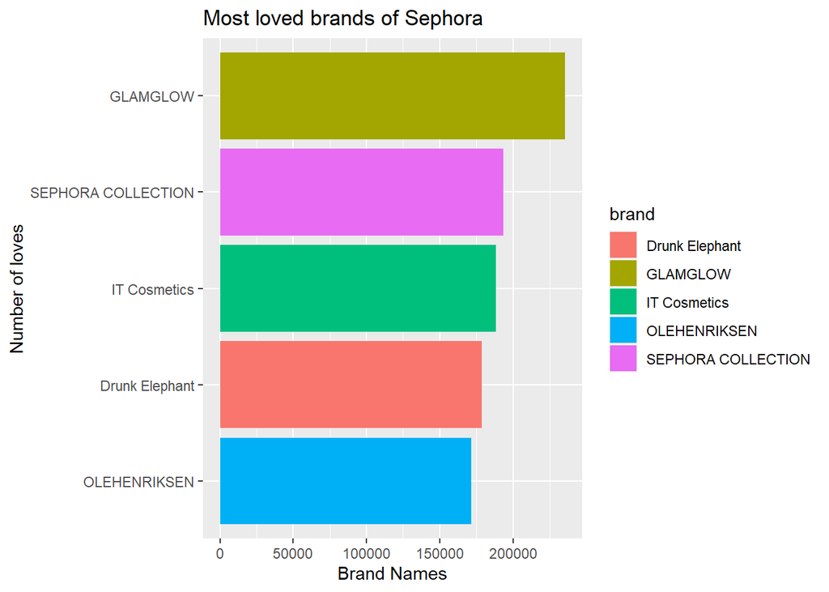

```r
library(ggplot2)
library(tidyverse)
#plotting the number of loves against brands after grouping
plot_1<-data %>% group_by(brand) %>% summarize(most_loved= max(n_of_loves)) %>% top_n(5) %>% ggplot(aes(x=reorder(brand,most_loved), y=most_loved, fill= brand)) + xlab("Number of loves")+ ylab("Brand Names") + ggtitle("Most loved brands of Sephora")+ geom_bar(stat = 'identity') + coord_flip()
#displaying the result
plot_1
```

It can be inferred from the graph (plot_1) that **“GLAMGLOW” is the most loved brand with over 200000 likes**. This is followed by “SEPHORA COLLECTION” and “IT Cosmetics.”Drunk Elephant” and “OLEHENRIKSEN” come at the last with likes that range between 150000 and 200000.

**2. COSTLIEST BRANDS AT SEPHORA**

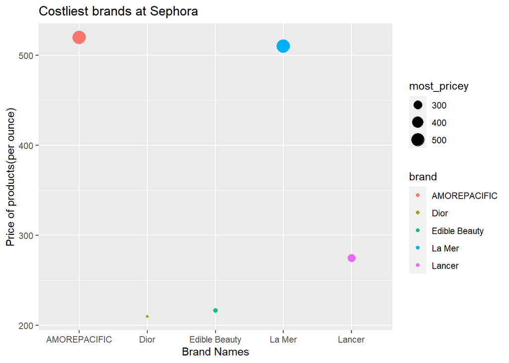

```r
#
plot_2<-data%>%
  group_by(brand)%>%
  summarize(most_pricey= max(price_per_ounce))%>%
  top_n(5) %>%
  ggplot(aes(x = brand, y = most_pricey, color=brand, size= most_pricey))+
  ylab("Price of products(per ounce)") +
  xlab("Brand Names") +
  ggtitle("Costliest brands at Sephora")+
  geom_point()
plot_2
```

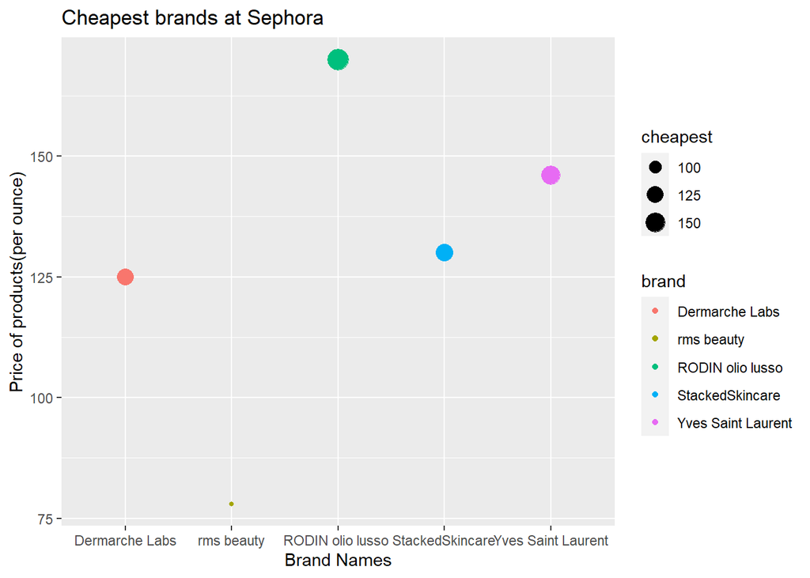

```r
plot_3<-data%>%
  group_by(brand)%>%
  summarize(cheapest= min(price_per_ounce))%>%
  top_n(5) %>%
  ggplot(aes(x = brand, y = cheapest,color= brand,size= cheapest))+
  ylab("Price of products(per ounce)") +
  xlab("Brand Names") +
  ggtitle("Cheapest brands at Sephora")+
  geom_point() + scale_fill_gradient2(low="blue", high="red")
plot_3
```

**3. MOST EFFECTIVE BRANDS AT SEPHORA**

The next job was to determine the most effective brands at Sephora. There are three factors in this dataset that can determine the status (positive or negative) of a product: `review_score`, `n_of_loves` and `n_of_reviews`.

We first grouped the dataset in-terms of brand and then plotted the reviews-to-loves ratio against the brand.

```r
plot_4<-data%>%
  group_by(brand)%>%
  summarize(best_reviewed= min(reviews_to_loves_ratio))%>%
  top_n(5)
plot_4
```

```
## # A tibble: 5 × 2
##   brand                           best_reviewed
##   <chr>                                   <dbl>
## 1 "Acqua Di Parma"                         1.92
## 2 "Crushed Tonic"                          3.54
## 3 "RODIN olio lusso "                      2.19
## 4 "St. Tropez Tanning Essentials"          1.88
## 5 "Too Cool For School"                    3.18
```

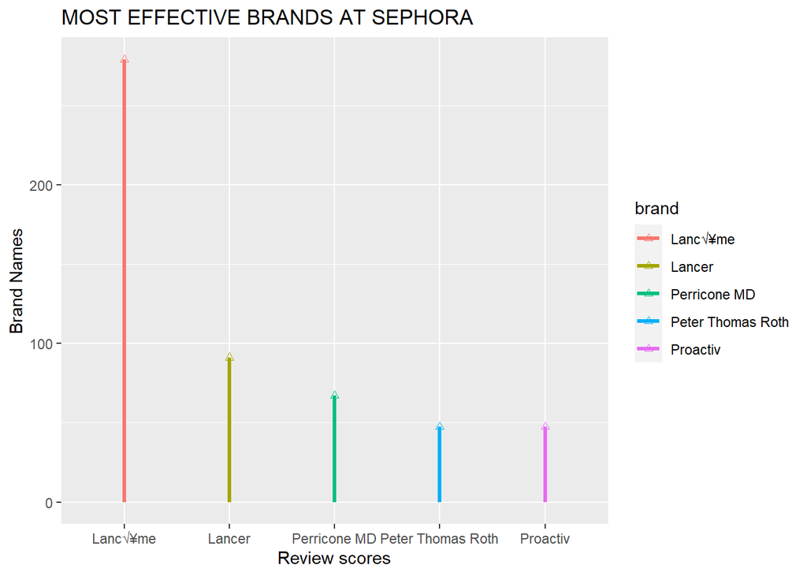

```r
plot_4<-data%>%
  group_by(brand)%>%
  summarize(best_reviewed= max(reviews_to_loves_ratio))%>%
  top_n(5) %>%
  ggplot(aes(x = brand, y = best_reviewed, color=brand)) +
  xlab("Review scores") +
  ylab("Brand Names") +
  ggtitle("MOST EFFECTIVE BRANDS AT SEPHORA")+
  geom_point(shape= 2)+geom_segment(aes(xend = brand, yend = 0), size = 1.2)
plot_4
```

Now, we will perform some brand-wise analysis.

```r
#this function gives a list of all the unique brands in this Dataset.
unique(data$brand)
```

```
##   [1] "Drunk Elephant"                "La Mer"
##   [3] "IT Cosmetics"                  "Tatcha"
##   [5] "SK-II"                         "The Ordinary"
##   [7] "Kiehl's Since 1851"            "belif"
##   [9] "bareMinerals"                  "SEPHORA COLLECTION"
##  [11] "Fresh"                         "Farmacy"
##  [13] "CLINIQUE"                      "First Aid Beauty"
##  [15] "OLEHENRIKSEN"                  "Supergoop!"
##  [17] "Dr. Jart+"                     "SUNDAY RILEY"
##  [19] "Glow Recipe"                   "Caudalie"
##  [21] "Erborian"                      "Youth To The People"
##  [23] "Charlotte Tilbury"             "LANEIGE"
##  [25] "Bobbi Brown"                   "Josie Maran"
##  [27] "Origins"                       "tarte"
##  [29] "Biossance"                     "FARSALI"
```

[output cut: 56 more lines]

There are 141 different brands in this dataset. Let us check for brands that have the most number of products.

Before that, let us check to see how many duplicate values still remain.

```r
data1<-unique(data)
sum(duplicated(data1))
```

```
## [1] 0
```

We are good to go, since there are no duplicate values.

```r
brand_freq<-table(data1$brand)
brand_freq<-as.data.frame(brand_freq) %>% rename(brand_name = Var1) %>% arrange(desc(Freq))
brand_freq
```

```
##                        brand_name Freq
## 1                        CLINIQUE   63
## 2                           Murad   53
## 3                        Shiseido   52
## 4                    Perricone MD   51
## 5                         Origins   43
## 6              Kiehl's Since 1851   41
## 7                 Kate Somerville   40
## 8               Peter Thomas Roth   40
## 9                   Est√©e Lauder   38
## 10                          Fresh   38
## 11                       Algenist   35
## 12                       Lanc√¥me   35
## 13                     philosophy   34
## 14                       Caudalie   32
```

[output cut: 127 more lines]

The above table shows that “Clinique” brand has the highest number of products out in the Sephora retail space. Now, we make a plot of this data.

```r
#converting the column "brand_name" into a character in order to plot it
brand_freq$brand_name<-as.character(brand_freq$brand_name)
```

```r
#identifying the class of brand_name
class(brand_freq$brand_name)
```

```
## [1] "character"
```

```r
#arranging brand_freq in terms of descending order of Frequency
desc_df<-brand_freq %>% arrange(desc(Freq))
```

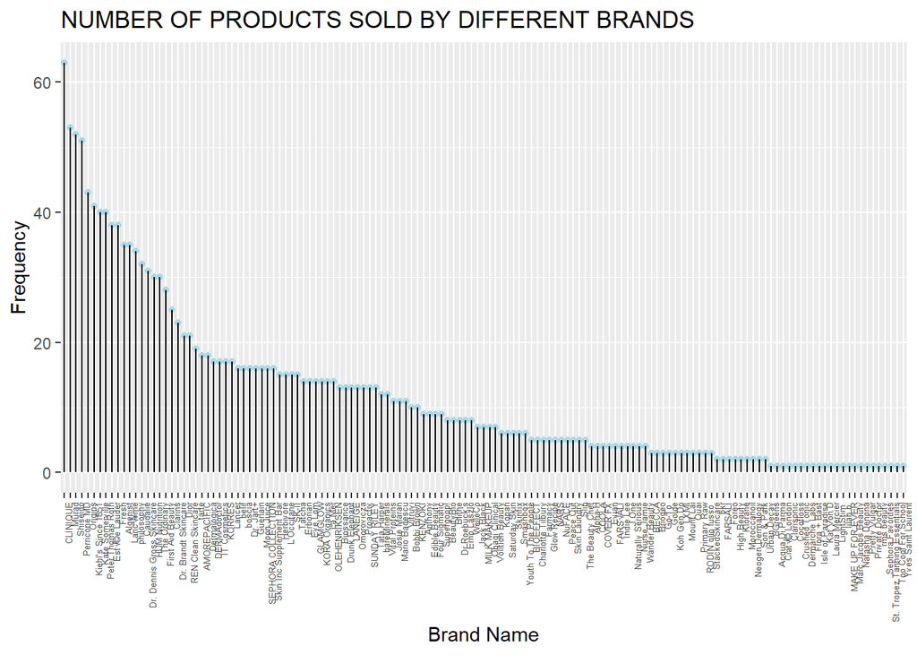

```r
#plotting a graph of the brands that have the most variety of products
plot5<-desc_df %>%
  ggplot(aes(x=reorder(brand_name,- Freq), y=Freq)) +
  geom_point(color="light blue") +
  geom_segment(aes(xend = brand_name, yend = 0))+
  theme(axis.text.x = element_text(angle = 90, hjust = 1, size = 5))+
  xlab("Brand Name") + ylab("Frequency")+ggtitle("NUMBER OF PRODUCTS SOLD BY DIFFERENT BRANDS")
plot5
```

As we can see from the above plot, Clinique is closely folled by the brands Murad and Sheseido. This means that these three brands have the most diverse number of products in the market. On the other hand, brands like Yves Saint Laurent, rms beauty and Marc Jacobs Beauty have the least variety of products on sale.

**CONCLUSIONS**

The only costly brand at Sephora that has a good product diversity and is effective is **Lancer**.

**POSSIBLE BIAS**

1. Assuming the reviews talk for everyone–the reviews may probably be extremely biased and cater towards only one specific part of the demographic (particularly in terms of skin texture and color). For instance, the brand Tarte recently issued a public apology after being accused of a shade range that mostly leaned towards caucasian skin types.
2. People assume that costly brands perform better but our inferences show otherwise. Lancer is the only brand that fits this assumption and all the other costly brands, in fact, have neither a diverse line of products, nor great “loves” and “reviews”.

[output not shown]

```r
print(sI, RNG = TRUE, locale = FALSE)
```

[output not shown]

```r
toLatex(sI, locale = FALSE)
```

```
## \begin{itemize}\raggedright
##   \item R version 4.2.1 (2022-06-23 ucrt), \verb|x86_64-w64-mingw32|
##   \item Running under: \verb|Windows 10 x64 (build 22000)|
##   \item Matrix products: default
##   \item Base packages: base, datasets, graphics, grDevices, methods,
##     stats, utils
##   \item Other packages: dplyr~1.0.10, forcats~0.5.2, ggplot2~3.4.0,
##     purrr~0.3.5, readr~2.1.3, stringr~1.4.1, tibble~3.1.8, tidyr~1.2.1,
##     tidyverse~1.3.2
##   \item Loaded via a namespace (and not attached): assertthat~0.2.1,
##     backports~1.4.1, broom~1.0.1, bslib~0.4.1, cachem~1.0.6,
##     cellranger~1.1.0, cli~3.4.1, colorspace~2.0-3, compiler~4.2.1,
##     crayon~1.5.2, DBI~1.1.3, dbplyr~2.2.1, digest~0.6.29,
##     ellipsis~0.3.2, evaluate~0.17, fansi~1.0.3, farver~2.1.1,
##     fastmap~1.1.0, fs~1.5.2, gargle~1.2.1, generics~0.1.3, glue~1.6.2,
##     googledrive~2.0.0, googlesheets4~1.0.1, grid~4.2.1, gtable~0.3.1,
##     haven~2.5.1, highr~0.9, hms~1.1.2, htmltools~0.5.3, httr~1.4.4,
##     jquerylib~0.1.4, jsonlite~1.8.3, knitr~1.40, labeling~0.4.2,
##     lifecycle~1.0.3, lubridate~1.8.0, magrittr~2.0.3, modelr~0.1.9,
##     munsell~0.5.0, pillar~1.8.1, pkgconfig~2.0.3, R6~2.5.1,
##     readxl~1.4.1, reprex~2.0.2, rlang~1.0.6, rmarkdown~2.17,
##     rstudioapi~0.14, rvest~1.0.3, sass~0.4.2, scales~1.2.1,
##     stringi~1.7.8, tidyselect~1.2.0, tools~4.2.1, tzdb~0.3.0,
##     utf8~1.2.2, vctrs~0.5.1, withr~2.5.0, xfun~0.33, xml2~1.3.3,
##     yaml~2.3.6
## \end{itemize}
```

[output not shown]